# Risk Factor Analysis

## Outcome Variable

**Outcome Variable:** pers_wast

## Predictor Variables

**Intervention Variable:** birthwt

**Adjustment Set:**

- arm
- sex
- W_mage
- meducyrs
- feducyrs
- vagbrth
- single
- brthmon
- W_parity
- delta_W_mage
- delta_meducyrs
- delta_feducyrs
- delta_vagbrth
- delta_single
- delta_brthmon
- delta_W_parity

## Stratifying Variables

The analysis was stratified on these variable(s):

- agecat
- studyid
- country

## Data Summary

| agecat | studyid | country | birthwt | pers_wast | n_cell | n |
| --- | --- | --- | --- | --- | --- | --- |
| 0-24 months | CMC-V-BCS-2002 | INDIA | Normal or high birthweight | 0 | 305 | 365 |
| 0-24 months | CMC-V-BCS-2002 | INDIA | Normal or high birthweight | 1 | 17 | 365 |
| 0-24 months | CMC-V-BCS-2002 | INDIA | Low birthweight | 0 | 38 | 365 |
| 0-24 months | CMC-V-BCS-2002 | INDIA | Low birthweight | 1 | 5 | 365 |
| 0-24 months | CMIN | BANGLADESH | Normal or high birthweight | 0 | 9 | 12 |
| 0-24 months | CMIN | BANGLADESH | Normal or high birthweight | 1 | 0 | 12 |
| 0-24 months | CMIN | BANGLADESH | Low birthweight | 0 | 3 | 12 |
| 0-24 months | CMIN | BANGLADESH | Low birthweight | 1 | 0 | 12 |
| 0-24 months | COHORTS | GUATEMALA | Normal or high birthweight | 0 | 706 | 795 |
| 0-24 months | COHORTS | GUATEMALA | Normal or high birthweight | 1 | 17 | 795 |
| 0-24 months | COHORTS | GUATEMALA | Low birthweight | 0 | 69 | 795 |
| 0-24 months | COHORTS | GUATEMALA | Low birthweight | 1 | 3 | 795 |
| 0-24 months | COHORTS | INDIA | Normal or high birthweight | 0 | 3998 | 5268 |
| 0-24 months | COHORTS | INDIA | Normal or high birthweight | 1 | 281 | 5268 |
| 0-24 months | COHORTS | INDIA | Low birthweight | 0 | 763 | 5268 |
| 0-24 months | COHORTS | INDIA | Low birthweight | 1 | 226 | 5268 |
| 0-24 months | COHORTS | PHILIPPINES | Normal or high birthweight | 0 | 2409 | 2768 |
| 0-24 months | COHORTS | PHILIPPINES | Normal or high birthweight | 1 | 106 | 2768 |
| 0-24 months | COHORTS | PHILIPPINES | Low birthweight | 0 | 219 | 2768 |
| 0-24 months | COHORTS | PHILIPPINES | Low birthweight | 1 | 34 | 2768 |
| 0-24 months | CONTENT | PERU | Normal or high birthweight | 0 | 2 | 2 |
| 0-24 months | CONTENT | PERU | Normal or high birthweight | 1 | 0 | 2 |
| 0-24 months | CONTENT | PERU | Low birthweight | 0 | 0 | 2 |
| 0-24 months | CONTENT | PERU | Low birthweight | 1 | 0 | 2 |
| 0-24 months | EE | PAKISTAN | Normal or high birthweight | 0 | 225 | 376 |
| 0-24 months | EE | PAKISTAN | Normal or high birthweight | 1 | 19 | 376 |
| 0-24 months | EE | PAKISTAN | Low birthweight | 0 | 118 | 376 |
| 0-24 months | EE | PAKISTAN | Low birthweight | 1 | 14 | 376 |
| 0-24 months | GMS-Nepal | NEPAL | Normal or high birthweight | 0 | 378 | 596 |
| 0-24 months | GMS-Nepal | NEPAL | Normal or high birthweight | 1 | 40 | 596 |

[output cut: 278 more lines]

The following strata were considered:

- agecat: 0-24 months, studyid: CMC-V-BCS-2002, country: INDIA
- agecat: 0-24 months, studyid: CMIN, country: BANGLADESH
- agecat: 0-24 months, studyid: COHORTS, country: GUATEMALA
- agecat: 0-24 months, studyid: COHORTS, country: INDIA
- agecat: 0-24 months, studyid: COHORTS, country: PHILIPPINES
- agecat: 0-24 months, studyid: CONTENT, country: PERU
- agecat: 0-24 months, studyid: EE, country: PAKISTAN
- agecat: 0-24 months, studyid: GMS-Nepal, country: NEPAL
- agecat: 0-24 months, studyid: IRC, country: INDIA
- agecat: 0-24 months, studyid: JiVitA-3, country: BANGLADESH
- agecat: 0-24 months, studyid: JiVitA-4, country: BANGLADESH
- agecat: 0-24 months, studyid: Keneba, country: GAMBIA
- agecat: 0-24 months, studyid: MAL-ED, country: BANGLADESH
- agecat: 0-24 months, studyid: MAL-ED, country: BRAZIL
- agecat: 0-24 months, studyid: MAL-ED, country: INDIA
- agecat: 0-24 months, studyid: MAL-ED, country: NEPAL
- agecat: 0-24 months, studyid: MAL-ED, country: PERU
- agecat: 0-24 months, studyid: MAL-ED, country: SOUTH AFRICA
- agecat: 0-24 months, studyid: MAL-ED, country: TANZANIA, UNITED REPUBLIC OF
- agecat: 0-24 months, studyid: NIH-Birth, country: BANGLADESH
- agecat: 0-24 months, studyid: NIH-Crypto, country: BANGLADESH
- agecat: 0-24 months, studyid: PROBIT, country: BELARUS
- agecat: 0-24 months, studyid: PROVIDE, country: BANGLADESH
- agecat: 0-24 months, studyid: ResPak, country: PAKISTAN
- agecat: 0-24 months, studyid: SAS-CompFeed, country: INDIA
- agecat: 0-24 months, studyid: TanzaniaChild2, country: TANZANIA, UNITED REPUBLIC OF
- agecat: 0-24 months, studyid: ZVITAMBO, country: ZIMBABWE
- agecat: 0-6 months, studyid: CMC-V-BCS-2002, country: INDIA
- agecat: 0-6 months, studyid: CMIN, country: BANGLADESH
- agecat: 0-6 months, studyid: COHORTS, country: PHILIPPINES
- agecat: 0-6 months, studyid: CONTENT, country: PERU
- agecat: 0-6 months, studyid: EE, country: PAKISTAN
- agecat: 0-6 months, studyid: GMS-Nepal, country: NEPAL
- agecat: 0-6 months, studyid: IRC, country: INDIA
- agecat: 0-6 months, studyid: JiVitA-3, country: BANGLADESH
- agecat: 0-6 months, studyid: Keneba, country: GAMBIA
- agecat: 0-6 months, studyid: MAL-ED, country: BANGLADESH
- agecat: 0-6 months, studyid: MAL-ED, country: BRAZIL
- agecat: 0-6 months, studyid: MAL-ED, country: INDIA
- agecat: 0-6 months, studyid: MAL-ED, country: NEPAL
- agecat: 0-6 months, studyid: MAL-ED, country: PERU
- agecat: 0-6 months, studyid: MAL-ED, country: SOUTH AFRICA
- agecat: 0-6 months, studyid: MAL-ED, country: TANZANIA, UNITED REPUBLIC OF
- agecat: 0-6 months, studyid: NIH-Birth, country: BANGLADESH
- agecat: 0-6 months, studyid: NIH-Crypto, country: BANGLADESH
- agecat: 0-6 months, studyid: PROBIT, country: BELARUS
- agecat: 0-6 months, studyid: PROVIDE, country: BANGLADESH
- agecat: 0-6 months, studyid: ResPak, country: PAKISTAN
- agecat: 0-6 months, studyid: TanzaniaChild2, country: TANZANIA, UNITED REPUBLIC OF
- agecat: 0-6 months, studyid: ZVITAMBO, country: ZIMBABWE
- agecat: 6-24 months, studyid: CMC-V-BCS-2002, country: INDIA
- agecat: 6-24 months, studyid: CMIN, country: BANGLADESH
- agecat: 6-24 months, studyid: COHORTS, country: GUATEMALA
- agecat: 6-24 months, studyid: COHORTS, country: INDIA
- agecat: 6-24 months, studyid: COHORTS, country: PHILIPPINES
- agecat: 6-24 months, studyid: CONTENT, country: PERU
- agecat: 6-24 months, studyid: EE, country: PAKISTAN
- agecat: 6-24 months, studyid: GMS-Nepal, country: NEPAL
- agecat: 6-24 months, studyid: IRC, country: INDIA
- agecat: 6-24 months, studyid: JiVitA-3, country: BANGLADESH
- agecat: 6-24 months, studyid: JiVitA-4, country: BANGLADESH
- agecat: 6-24 months, studyid: Keneba, country: GAMBIA
- agecat: 6-24 months, studyid: MAL-ED, country: BANGLADESH
- agecat: 6-24 months, studyid: MAL-ED, country: BRAZIL
- agecat: 6-24 months, studyid: MAL-ED, country: INDIA
- agecat: 6-24 months, studyid: MAL-ED, country: NEPAL
- agecat: 6-24 months, studyid: MAL-ED, country: PERU
- agecat: 6-24 months, studyid: MAL-ED, country: SOUTH AFRICA
- agecat: 6-24 months, studyid: MAL-ED, country: TANZANIA, UNITED REPUBLIC OF
- agecat: 6-24 months, studyid: NIH-Birth, country: BANGLADESH
- agecat: 6-24 months, studyid: NIH-Crypto, country: BANGLADESH
- agecat: 6-24 months, studyid: PROBIT, country: BELARUS
- agecat: 6-24 months, studyid: PROVIDE, country: BANGLADESH
- agecat: 6-24 months, studyid: ResPak, country: PAKISTAN
- agecat: 6-24 months, studyid: SAS-CompFeed, country: INDIA
- agecat: 6-24 months, studyid: TanzaniaChild2, country: TANZANIA, UNITED REPUBLIC OF
- agecat: 6-24 months, studyid: ZVITAMBO, country: ZIMBABWE

### Dropped Strata

Some strata were dropped due to rare outcomes:

- agecat: 0-24 months, studyid: CMIN, country: BANGLADESH
- agecat: 0-24 months, studyid: COHORTS, country: GUATEMALA
- agecat: 0-24 months, studyid: CONTENT, country: PERU
- agecat: 0-24 months, studyid: MAL-ED, country: BANGLADESH
- agecat: 0-24 months, studyid: MAL-ED, country: BRAZIL
- agecat: 0-24 months, studyid: MAL-ED, country: NEPAL
- agecat: 0-24 months, studyid: MAL-ED, country: PERU
- agecat: 0-24 months, studyid: MAL-ED, country: SOUTH AFRICA
- agecat: 0-24 months, studyid: MAL-ED, country: TANZANIA, UNITED REPUBLIC OF
- agecat: 0-24 months, studyid: PROBIT, country: BELARUS
- agecat: 0-24 months, studyid: ResPak, country: PAKISTAN
- agecat: 0-6 months, studyid: CMIN, country: BANGLADESH
- agecat: 0-6 months, studyid: CONTENT, country: PERU
- agecat: 0-6 months, studyid: JiVitA-3, country: BANGLADESH
- agecat: 0-6 months, studyid: MAL-ED, country: BANGLADESH
- agecat: 0-6 months, studyid: MAL-ED, country: BRAZIL
- agecat: 0-6 months, studyid: MAL-ED, country: NEPAL
- agecat: 0-6 months, studyid: MAL-ED, country: PERU
- agecat: 0-6 months, studyid: MAL-ED, country: SOUTH AFRICA
- agecat: 0-6 months, studyid: MAL-ED, country: TANZANIA, UNITED REPUBLIC OF
- agecat: 0-6 months, studyid: NIH-Birth, country: BANGLADESH
- agecat: 0-6 months, studyid: NIH-Crypto, country: BANGLADESH
- agecat: 0-6 months, studyid: PROBIT, country: BELARUS
- agecat: 0-6 months, studyid: ResPak, country: PAKISTAN
- agecat: 0-6 months, studyid: ZVITAMBO, country: ZIMBABWE
- agecat: 6-24 months, studyid: CMIN, country: BANGLADESH
- agecat: 6-24 months, studyid: COHORTS, country: GUATEMALA
- agecat: 6-24 months, studyid: CONTENT, country: PERU
- agecat: 6-24 months, studyid: MAL-ED, country: BANGLADESH
- agecat: 6-24 months, studyid: MAL-ED, country: BRAZIL
- agecat: 6-24 months, studyid: MAL-ED, country: NEPAL
- agecat: 6-24 months, studyid: MAL-ED, country: PERU
- agecat: 6-24 months, studyid: MAL-ED, country: SOUTH AFRICA
- agecat: 6-24 months, studyid: MAL-ED, country: TANZANIA, UNITED REPUBLIC OF
- agecat: 6-24 months, studyid: PROBIT, country: BELARUS
- agecat: 6-24 months, studyid: ResPak, country: PAKISTAN

## Methods Detail

We’re interested in the causal parameters $E[Y_a]$ for all values of $a \in \mathcal{A}$. These parameters represent the mean outcome if, possibly contrary to fact, we intervened to set all units to have $A=a$. Under the randomization and positivity assumptions, these are identified by the statistical parameters $\psi_a=E_W[E_{Y|A,W}(Y|A=a,W)]$. In addition, we’re interested in the mean of $Y$, $E[Y]$ under no intervention (the observed mean). We will estimate these parameters by using SuperLearner to fit the relevant likelihood factors – $E_{Y|A,W}(Y|A=a,W)$ and $p(A=a|W)$, and then updating our likelihood fit using a joint TMLE.

For unadjusted analyses ($W=\{\}$), initial likelihoods were estimated using Lrnr_glm to estimate the simple $E(Y|A)$ and Lrnr_mean to estimate $p(A)$. For adjusted analyses, a small library containing Lrnr_glmnet, Lrnr_xgboost, and Lrnr_mean was used.

Having estimated these parameters, we will then use the delta method to estimate relative risks and attributable risks relative to a prespecified baseline level of $A$.

# Results Detail

## Results Plots

[figure not shown]

[figure not shown]

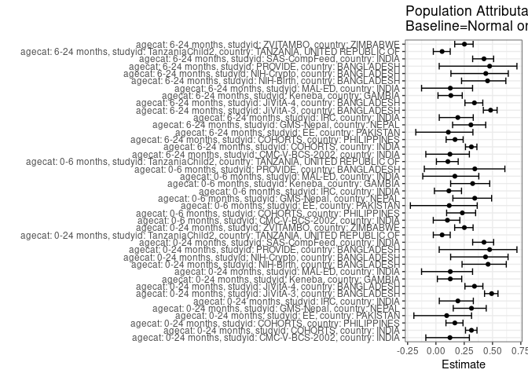

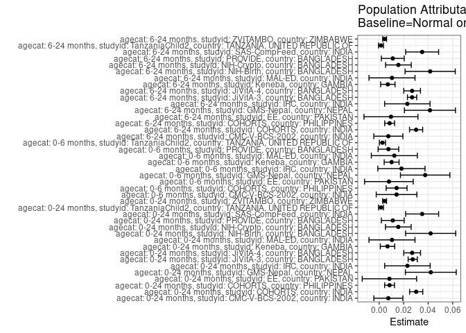

## Results Table

### Parameter: TSM

| agecat | studyid | country | intervention_level | baseline_level | estimate | ci_lower | ci_upper |
| --- | --- | --- | --- | --- | --- | --- | --- |
| 0-24 months | CMC-V-BCS-2002 | INDIA | Normal or high birthweight | NA | 0.0527950 | 0.0283363 | 0.0772538 |
| 0-24 months | CMC-V-BCS-2002 | INDIA | Low birthweight | NA | 0.1162791 | 0.0203350 | 0.2122231 |
| 0-24 months | COHORTS | INDIA | Normal or high birthweight | NA | 0.0660235 | 0.0585607 | 0.0734862 |
| 0-24 months | COHORTS | INDIA | Low birthweight | NA | 0.2239445 | 0.1974667 | 0.2504222 |
| 0-24 months | COHORTS | PHILIPPINES | Normal or high birthweight | NA | 0.0421142 | 0.0342608 | 0.0499676 |
| 0-24 months | COHORTS | PHILIPPINES | Low birthweight | NA | 0.1333454 | 0.0920865 | 0.1746043 |
| 0-24 months | EE | PAKISTAN | Normal or high birthweight | NA | 0.0794076 | 0.0453147 | 0.1135005 |
| 0-24 months | EE | PAKISTAN | Low birthweight | NA | 0.1042520 | 0.0518337 | 0.1566703 |
| 0-24 months | GMS-Nepal | NEPAL | Normal or high birthweight | NA | 0.0920592 | 0.0642595 | 0.1198589 |
| 0-24 months | GMS-Nepal | NEPAL | Low birthweight | NA | 0.2230813 | 0.1621333 | 0.2840293 |
| 0-24 months | IRC | INDIA | Normal or high birthweight | NA | 0.0957473 | 0.0642152 | 0.1272795 |
| 0-24 months | IRC | INDIA | Low birthweight | NA | 0.2360640 | 0.1350737 | 0.3370543 |
| 0-24 months | JiVitA-3 | BANGLADESH | Normal or high birthweight | NA | 0.0282356 | 0.0240926 | 0.0323787 |
| 0-24 months | JiVitA-3 | BANGLADESH | Low birthweight | NA | 0.0998939 | 0.0907042 | 0.1090836 |
| 0-24 months | JiVitA-4 | BANGLADESH | Normal or high birthweight | NA | 0.0521985 | 0.0432921 | 0.0611049 |
| 0-24 months | JiVitA-4 | BANGLADESH | Low birthweight | NA | 0.1535721 | 0.1300772 | 0.1770671 |
| 0-24 months | Keneba | GAMBIA | Normal or high birthweight | NA | 0.0466868 | 0.0350969 | 0.0582768 |
| 0-24 months | Keneba | GAMBIA | Low birthweight | NA | 0.0927909 | 0.0543526 | 0.1312292 |
| 0-24 months | MAL-ED | INDIA | Normal or high birthweight | NA | 0.0717949 | 0.0354836 | 0.1081062 |
| 0-24 months | MAL-ED | INDIA | Low birthweight | NA | 0.1388889 | 0.0256743 | 0.2521034 |
| 0-24 months | NIH-Birth | BANGLADESH | Normal or high birthweight | NA | 0.0492242 | 0.0267442 | 0.0717041 |
| 0-24 months | NIH-Birth | BANGLADESH | Low birthweight | NA | 0.1951866 | 0.1320025 | 0.2583708 |
| 0-24 months | NIH-Crypto | BANGLADESH | Normal or high birthweight | NA | 0.0200066 | 0.0083577 | 0.0316555 |
| 0-24 months | NIH-Crypto | BANGLADESH | Low birthweight | NA | 0.0844869 | 0.0423886 | 0.1265852 |
| 0-24 months | PROVIDE | BANGLADESH | Normal or high birthweight | NA | 0.0122951 | 0.0025102 | 0.0220800 |
| 0-24 months | PROVIDE | BANGLADESH | Low birthweight | NA | 0.0588235 | 0.0215112 | 0.0961359 |
| 0-24 months | SAS-CompFeed | INDIA | Normal or high birthweight | NA | 0.0475142 | 0.0324666 | 0.0625617 |
| 0-24 months | SAS-CompFeed | INDIA | Low birthweight | NA | 0.1883246 | 0.1312427 | 0.2454066 |
| 0-24 months | TanzaniaChild2 | TANZANIA, UNITED REPUBLIC OF | Normal or high birthweight | NA | 0.0251451 | 0.0183956 | 0.0318946 |
| 0-24 months | TanzaniaChild2 | TANZANIA, UNITED REPUBLIC OF | Low birthweight | NA | 0.0666667 | 0.0102001 | 0.1231333 |

[output cut: 52 more lines]

### Parameter: E(Y)

| agecat | studyid | country | intervention_level | baseline_level | estimate | ci_lower | ci_upper |
| --- | --- | --- | --- | --- | --- | --- | --- |
| 0-24 months | CMC-V-BCS-2002 | INDIA | NA | NA | 0.0602740 | 0.0358249 | 0.0847231 |
| 0-24 months | COHORTS | INDIA | NA | NA | 0.0962415 | 0.0882767 | 0.1042062 |
| 0-24 months | COHORTS | PHILIPPINES | NA | NA | 0.0505780 | 0.0424131 | 0.0587430 |
| 0-24 months | EE | PAKISTAN | NA | NA | 0.0877660 | 0.0591276 | 0.1164044 |
| 0-24 months | GMS-Nepal | NEPAL | NA | NA | 0.1342282 | 0.1068369 | 0.1616195 |
| 0-24 months | IRC | INDIA | NA | NA | 0.1188119 | 0.0872211 | 0.1504026 |
| 0-24 months | JiVitA-3 | BANGLADESH | NA | NA | 0.0556259 | 0.0512873 | 0.0599644 |
| 0-24 months | JiVitA-4 | BANGLADESH | NA | NA | 0.0791432 | 0.0700117 | 0.0882747 |
| 0-24 months | Keneba | GAMBIA | NA | NA | 0.0534759 | 0.0420715 | 0.0648803 |
| 0-24 months | MAL-ED | INDIA | NA | NA | 0.0822511 | 0.0467438 | 0.1177583 |
| 0-24 months | NIH-Birth | BANGLADESH | NA | NA | 0.0912621 | 0.0663660 | 0.1161582 |
| 0-24 months | NIH-Crypto | BANGLADESH | NA | NA | 0.0356164 | 0.0221630 | 0.0490699 |
| 0-24 months | PROVIDE | BANGLADESH | NA | NA | 0.0234009 | 0.0116889 | 0.0351130 |
| 0-24 months | SAS-CompFeed | INDIA | NA | NA | 0.0825959 | 0.0584656 | 0.1067261 |
| 0-24 months | TanzaniaChild2 | TANZANIA, UNITED REPUBLIC OF | NA | NA | 0.0265982 | 0.0197841 | 0.0334124 |
| 0-24 months | ZVITAMBO | ZIMBABWE | NA | NA | 0.0176823 | 0.0150321 | 0.0203326 |
| 0-6 months | CMC-V-BCS-2002 | INDIA | NA | NA | 0.1396011 | 0.1032926 | 0.1759097 |
| 0-6 months | COHORTS | PHILIPPINES | NA | NA | 0.0609613 | 0.0448957 | 0.0770269 |
| 0-6 months | EE | PAKISTAN | NA | NA | 0.0675676 | 0.0419574 | 0.0931778 |
| 0-6 months | GMS-Nepal | NEPAL | NA | NA | 0.1095406 | 0.0837882 | 0.1352931 |
| 0-6 months | IRC | INDIA | NA | NA | 0.1586902 | 0.1227025 | 0.1946778 |
| 0-6 months | Keneba | GAMBIA | NA | NA | 0.0312945 | 0.0221903 | 0.0403986 |
| 0-6 months | MAL-ED | INDIA | NA | NA | 0.0739130 | 0.0400273 | 0.1077988 |
| 0-6 months | PROVIDE | BANGLADESH | NA | NA | 0.0219436 | 0.0105669 | 0.0333202 |
| 0-6 months | TanzaniaChild2 | TANZANIA, UNITED REPUBLIC OF | NA | NA | 0.0250000 | 0.0182234 | 0.0317766 |
| 6-24 months | CMC-V-BCS-2002 | INDIA | NA | NA | 0.0602740 | 0.0358249 | 0.0847231 |
| 6-24 months | COHORTS | INDIA | NA | NA | 0.0962415 | 0.0882767 | 0.1042062 |
| 6-24 months | COHORTS | PHILIPPINES | NA | NA | 0.0505780 | 0.0424131 | 0.0587430 |
| 6-24 months | EE | PAKISTAN | NA | NA | 0.0877660 | 0.0591276 | 0.1164044 |
| 6-24 months | GMS-Nepal | NEPAL | NA | NA | 0.1342282 | 0.1068369 | 0.1616195 |
| 6-24 months | IRC | INDIA | NA | NA | 0.1188119 | 0.0872211 | 0.1504026 |
| 6-24 months | JiVitA-3 | BANGLADESH | NA | NA | 0.0556259 | 0.0512873 | 0.0599644 |
| 6-24 months | JiVitA-4 | BANGLADESH | NA | NA | 0.0791432 | 0.0700117 | 0.0882747 |
| 6-24 months | Keneba | GAMBIA | NA | NA | 0.0534759 | 0.0420715 | 0.0648803 |
| 6-24 months | MAL-ED | INDIA | NA | NA | 0.0822511 | 0.0467438 | 0.1177583 |
| 6-24 months | NIH-Birth | BANGLADESH | NA | NA | 0.0912621 | 0.0663660 | 0.1161582 |
| 6-24 months | NIH-Crypto | BANGLADESH | NA | NA | 0.0356164 | 0.0221630 | 0.0490699 |
| 6-24 months | PROVIDE | BANGLADESH | NA | NA | 0.0234009 | 0.0116889 | 0.0351130 |
| 6-24 months | SAS-CompFeed | INDIA | NA | NA | 0.0825959 | 0.0584656 | 0.1067261 |
| 6-24 months | TanzaniaChild2 | TANZANIA, UNITED REPUBLIC OF | NA | NA | 0.0265982 | 0.0197841 | 0.0334124 |
| 6-24 months | ZVITAMBO | ZIMBABWE | NA | NA | 0.0176823 | 0.0150321 | 0.0203326 |

### Parameter: RR

| agecat | studyid | country | intervention_level | baseline_level | estimate | ci_lower | ci_upper |
| --- | --- | --- | --- | --- | --- | --- | --- |
| 0-24 months | CMC-V-BCS-2002 | INDIA | Normal or high birthweight | Normal or high birthweight | 1.000000 | 1.0000000 | 1.000000 |
| 0-24 months | CMC-V-BCS-2002 | INDIA | Low birthweight | Normal or high birthweight | 2.202462 | 0.8549566 | 5.673786 |
| 0-24 months | COHORTS | INDIA | Normal or high birthweight | Normal or high birthweight | 1.000000 | 1.0000000 | 1.000000 |
| 0-24 months | COHORTS | INDIA | Low birthweight | Normal or high birthweight | 3.391892 | 2.8812584 | 3.993024 |
| 0-24 months | COHORTS | PHILIPPINES | Normal or high birthweight | Normal or high birthweight | 1.000000 | 1.0000000 | 1.000000 |
| 0-24 months | COHORTS | PHILIPPINES | Low birthweight | Normal or high birthweight | 3.166281 | 2.2074454 | 4.541600 |
| 0-24 months | EE | PAKISTAN | Normal or high birthweight | Normal or high birthweight | 1.000000 | 1.0000000 | 1.000000 |
| 0-24 months | EE | PAKISTAN | Low birthweight | Normal or high birthweight | 1.312871 | 0.6774241 | 2.544391 |
| 0-24 months | GMS-Nepal | NEPAL | Normal or high birthweight | Normal or high birthweight | 1.000000 | 1.0000000 | 1.000000 |
| 0-24 months | GMS-Nepal | NEPAL | Low birthweight | Normal or high birthweight | 2.423238 | 1.6081640 | 3.651419 |
| 0-24 months | IRC | INDIA | Normal or high birthweight | Normal or high birthweight | 1.000000 | 1.0000000 | 1.000000 |
| 0-24 months | IRC | INDIA | Low birthweight | Normal or high birthweight | 2.465489 | 1.4356587 | 4.234041 |
| 0-24 months | JiVitA-3 | BANGLADESH | Normal or high birthweight | Normal or high birthweight | 1.000000 | 1.0000000 | 1.000000 |
| 0-24 months | JiVitA-3 | BANGLADESH | Low birthweight | Normal or high birthweight | 3.537868 | 2.9873626 | 4.189819 |
| 0-24 months | JiVitA-4 | BANGLADESH | Normal or high birthweight | Normal or high birthweight | 1.000000 | 1.0000000 | 1.000000 |
| 0-24 months | JiVitA-4 | BANGLADESH | Low birthweight | Normal or high birthweight | 2.942079 | 2.3370689 | 3.703711 |
| 0-24 months | Keneba | GAMBIA | Normal or high birthweight | Normal or high birthweight | 1.000000 | 1.0000000 | 1.000000 |
| 0-24 months | Keneba | GAMBIA | Low birthweight | Normal or high birthweight | 1.987517 | 1.2265748 | 3.220532 |
| 0-24 months | MAL-ED | INDIA | Normal or high birthweight | Normal or high birthweight | 1.000000 | 1.0000000 | 1.000000 |
| 0-24 months | MAL-ED | INDIA | Low birthweight | Normal or high birthweight | 1.934524 | 0.7412333 | 5.048859 |
| 0-24 months | NIH-Birth | BANGLADESH | Normal or high birthweight | Normal or high birthweight | 1.000000 | 1.0000000 | 1.000000 |
| 0-24 months | NIH-Birth | BANGLADESH | Low birthweight | Normal or high birthweight | 3.965260 | 2.2605620 | 6.955477 |
| 0-24 months | NIH-Crypto | BANGLADESH | Normal or high birthweight | Normal or high birthweight | 1.000000 | 1.0000000 | 1.000000 |
| 0-24 months | NIH-Crypto | BANGLADESH | Low birthweight | Normal or high birthweight | 4.222952 | 1.9677265 | 9.062907 |
| 0-24 months | PROVIDE | BANGLADESH | Normal or high birthweight | Normal or high birthweight | 1.000000 | 1.0000000 | 1.000000 |
| 0-24 months | PROVIDE | BANGLADESH | Low birthweight | Normal or high birthweight | 4.784314 | 1.7291761 | 13.237320 |
| 0-24 months | SAS-CompFeed | INDIA | Normal or high birthweight | Normal or high birthweight | 1.000000 | 1.0000000 | 1.000000 |
| 0-24 months | SAS-CompFeed | INDIA | Low birthweight | Normal or high birthweight | 3.963545 | 3.0652924 | 5.125022 |
| 0-24 months | TanzaniaChild2 | TANZANIA, UNITED REPUBLIC OF | Normal or high birthweight | Normal or high birthweight | 1.000000 | 1.0000000 | 1.000000 |
| 0-24 months | TanzaniaChild2 | TANZANIA, UNITED REPUBLIC OF | Low birthweight | Normal or high birthweight | 2.651282 | 1.0903832 | 6.446630 |

[output cut: 52 more lines]

### Parameter: PAR

| agecat | studyid | country | intervention_level | baseline_level | estimate | ci_lower | ci_upper |
| --- | --- | --- | --- | --- | --- | --- | --- |
| 0-24 months | CMC-V-BCS-2002 | INDIA | Normal or high birthweight | NA | 0.0074789 | -0.0043735 | 0.0193314 |
| 0-24 months | COHORTS | INDIA | Normal or high birthweight | NA | 0.0302180 | 0.0248367 | 0.0355993 |
| 0-24 months | COHORTS | PHILIPPINES | Normal or high birthweight | NA | 0.0084638 | 0.0044515 | 0.0124762 |
| 0-24 months | EE | PAKISTAN | Normal or high birthweight | NA | 0.0083584 | -0.0138775 | 0.0305943 |
| 0-24 months | GMS-Nepal | NEPAL | Normal or high birthweight | NA | 0.0421690 | 0.0214048 | 0.0629332 |
| 0-24 months | IRC | INDIA | Normal or high birthweight | NA | 0.0230646 | 0.0044687 | 0.0416605 |
| 0-24 months | JiVitA-3 | BANGLADESH | Normal or high birthweight | NA | 0.0273903 | 0.0236399 | 0.0311406 |
| 0-24 months | JiVitA-4 | BANGLADESH | Normal or high birthweight | NA | 0.0269447 | 0.0201044 | 0.0337850 |
| 0-24 months | Keneba | GAMBIA | Normal or high birthweight | NA | 0.0067891 | 0.0009003 | 0.0126779 |
| 0-24 months | MAL-ED | INDIA | Normal or high birthweight | NA | 0.0104562 | -0.0083379 | 0.0292503 |
| 0-24 months | NIH-Birth | BANGLADESH | Normal or high birthweight | NA | 0.0420380 | 0.0215569 | 0.0625191 |
| 0-24 months | NIH-Crypto | BANGLADESH | Normal or high birthweight | NA | 0.0156098 | 0.0051287 | 0.0260909 |
| 0-24 months | PROVIDE | BANGLADESH | Normal or high birthweight | NA | 0.0111059 | 0.0017713 | 0.0204404 |
| 0-24 months | SAS-CompFeed | INDIA | Normal or high birthweight | NA | 0.0350817 | 0.0216207 | 0.0485427 |
| 0-24 months | TanzaniaChild2 | TANZANIA, UNITED REPUBLIC OF | Normal or high birthweight | NA | 0.0014532 | -0.0005632 | 0.0034695 |
| 0-24 months | ZVITAMBO | ZIMBABWE | Normal or high birthweight | NA | 0.0044446 | 0.0028657 | 0.0060234 |
| 0-6 months | CMC-V-BCS-2002 | INDIA | Normal or high birthweight | NA | 0.0141907 | -0.0024236 | 0.0308050 |
| 0-6 months | COHORTS | PHILIPPINES | Normal or high birthweight | NA | 0.0142222 | 0.0056795 | 0.0227650 |
| 0-6 months | EE | PAKISTAN | Normal or high birthweight | NA | 0.0079553 | -0.0119143 | 0.0278248 |
| 0-6 months | GMS-Nepal | NEPAL | Normal or high birthweight | NA | 0.0375633 | 0.0173791 | 0.0577476 |
| 0-6 months | IRC | INDIA | Normal or high birthweight | NA | 0.0181629 | -0.0011331 | 0.0374589 |
| 0-6 months | Keneba | GAMBIA | Normal or high birthweight | NA | 0.0101544 | 0.0040778 | 0.0162310 |
| 0-6 months | MAL-ED | INDIA | Normal or high birthweight | NA | 0.0123746 | -0.0064230 | 0.0311721 |
| 0-6 months | PROVIDE | BANGLADESH | Normal or high birthweight | NA | 0.0075403 | -0.0008617 | 0.0159423 |
| 0-6 months | TanzaniaChild2 | TANZANIA, UNITED REPUBLIC OF | Normal or high birthweight | NA | 0.0026423 | 0.0001425 | 0.0051420 |
| 6-24 months | CMC-V-BCS-2002 | INDIA | Normal or high birthweight | NA | 0.0074789 | -0.0043735 | 0.0193314 |
| 6-24 months | COHORTS | INDIA | Normal or high birthweight | NA | 0.0301645 | 0.0247980 | 0.0355309 |
| 6-24 months | COHORTS | PHILIPPINES | Normal or high birthweight | NA | 0.0085381 | 0.0045234 | 0.0125528 |
| 6-24 months | EE | PAKISTAN | Normal or high birthweight | NA | 0.0096211 | -0.0124265 | 0.0316686 |
| 6-24 months | GMS-Nepal | NEPAL | Normal or high birthweight | NA | 0.0414820 | 0.0206595 | 0.0623044 |
| 6-24 months | IRC | INDIA | Normal or high birthweight | NA | 0.0229908 | 0.0044440 | 0.0415377 |
| 6-24 months | JiVitA-3 | BANGLADESH | Normal or high birthweight | NA | 0.0268819 | 0.0230942 | 0.0306696 |
| 6-24 months | JiVitA-4 | BANGLADESH | Normal or high birthweight | NA | 0.0269118 | 0.0200983 | 0.0337253 |
| 6-24 months | Keneba | GAMBIA | Normal or high birthweight | NA | 0.0070604 | 0.0011869 | 0.0129338 |
| 6-24 months | MAL-ED | INDIA | Normal or high birthweight | NA | 0.0104562 | -0.0083379 | 0.0292503 |
| 6-24 months | NIH-Birth | BANGLADESH | Normal or high birthweight | NA | 0.0416433 | 0.0211485 | 0.0621381 |
| 6-24 months | NIH-Crypto | BANGLADESH | Normal or high birthweight | NA | 0.0156933 | 0.0052174 | 0.0261693 |
| 6-24 months | PROVIDE | BANGLADESH | Normal or high birthweight | NA | 0.0111059 | 0.0017713 | 0.0204404 |
| 6-24 months | SAS-CompFeed | INDIA | Normal or high birthweight | NA | 0.0350817 | 0.0216207 | 0.0485427 |
| 6-24 months | TanzaniaChild2 | TANZANIA, UNITED REPUBLIC OF | Normal or high birthweight | NA | 0.0014532 | -0.0005632 | 0.0034695 |
| 6-24 months | ZVITAMBO | ZIMBABWE | Normal or high birthweight | NA | 0.0044530 | 0.0028740 | 0.0060319 |

### Parameter: PAF

| agecat | studyid | country | intervention_level | baseline_level | estimate | ci_lower | ci_upper |
| --- | --- | --- | --- | --- | --- | --- | --- |
| 0-24 months | CMC-V-BCS-2002 | INDIA | Normal or high birthweight | NA | 0.1240824 | -0.0891428 | 0.2955638 |
| 0-24 months | COHORTS | INDIA | Normal or high birthweight | NA | 0.3139810 | 0.2614993 | 0.3627331 |
| 0-24 months | COHORTS | PHILIPPINES | Normal or high birthweight | NA | 0.1673419 | 0.0887255 | 0.2391759 |
| 0-24 months | EE | PAKISTAN | Normal or high birthweight | NA | 0.0952346 | -0.1947485 | 0.3148346 |
| 0-24 months | GMS-Nepal | NEPAL | Normal or high birthweight | NA | 0.3141590 | 0.1531600 | 0.4445493 |
| 0-24 months | IRC | INDIA | Normal or high birthweight | NA | 0.1941267 | 0.0298419 | 0.3305917 |
| 0-24 months | JiVitA-3 | BANGLADESH | Normal or high birthweight | NA | 0.4924012 | 0.4294807 | 0.5483824 |
| 0-24 months | JiVitA-4 | BANGLADESH | Normal or high birthweight | NA | 0.3404547 | 0.2564705 | 0.4149526 |
| 0-24 months | Keneba | GAMBIA | Normal or high birthweight | NA | 0.1269559 | 0.0128041 | 0.2279081 |
| 0-24 months | MAL-ED | INDIA | Normal or high birthweight | NA | 0.1271255 | -0.1267794 | 0.3238163 |
| 0-24 months | NIH-Birth | BANGLADESH | Normal or high birthweight | NA | 0.4606288 | 0.2309034 | 0.6217364 |
| 0-24 months | NIH-Crypto | BANGLADESH | Normal or high birthweight | NA | 0.4382762 | 0.1299668 | 0.6373315 |
| 0-24 months | PROVIDE | BANGLADESH | Normal or high birthweight | NA | 0.4745902 | 0.0290084 | 0.7156973 |
| 0-24 months | SAS-CompFeed | INDIA | Normal or high birthweight | NA | 0.4247390 | 0.3246016 | 0.5100296 |
| 0-24 months | TanzaniaChild2 | TANZANIA, UNITED REPUBLIC OF | Normal or high birthweight | NA | 0.0546337 | -0.0229578 | 0.1263399 |
| 0-24 months | ZVITAMBO | ZIMBABWE | Normal or high birthweight | NA | 0.2513553 | 0.1656348 | 0.3282690 |
| 0-6 months | CMC-V-BCS-2002 | INDIA | Normal or high birthweight | NA | 0.1016519 | -0.0233995 | 0.2114230 |
| 0-6 months | COHORTS | PHILIPPINES | Normal or high birthweight | NA | 0.2332990 | 0.0946194 | 0.3507368 |
| 0-6 months | EE | PAKISTAN | Normal or high birthweight | NA | 0.1177377 | -0.2254868 | 0.3648347 |
| 0-6 months | GMS-Nepal | NEPAL | Normal or high birthweight | NA | 0.3429169 | 0.1498522 | 0.4921375 |
| 0-6 months | IRC | INDIA | Normal or high birthweight | NA | 0.1144550 | -0.0133065 | 0.2261078 |
| 0-6 months | Keneba | GAMBIA | Normal or high birthweight | NA | 0.3244794 | 0.1300971 | 0.4754264 |
| 0-6 months | MAL-ED | INDIA | Normal or high birthweight | NA | 0.1674208 | -0.1161918 | 0.3789704 |
| 0-6 months | PROVIDE | BANGLADESH | Normal or high birthweight | NA | 0.3436214 | -0.1023367 | 0.6091640 |
| 0-6 months | TanzaniaChild2 | TANZANIA, UNITED REPUBLIC OF | Normal or high birthweight | NA | 0.1056911 | 0.0043545 | 0.1967136 |
| 6-24 months | CMC-V-BCS-2002 | INDIA | Normal or high birthweight | NA | 0.1240824 | -0.0891428 | 0.2955638 |
| 6-24 months | COHORTS | INDIA | Normal or high birthweight | NA | 0.3134249 | 0.2611676 | 0.3619861 |
| 6-24 months | COHORTS | PHILIPPINES | Normal or high birthweight | NA | 0.1688101 | 0.0902194 | 0.2406117 |
| 6-24 months | EE | PAKISTAN | Normal or high birthweight | NA | 0.1096221 | -0.1777898 | 0.3268978 |
| 6-24 months | GMS-Nepal | NEPAL | Normal or high birthweight | NA | 0.3090406 | 0.1474637 | 0.4399946 |
| 6-24 months | IRC | INDIA | Normal or high birthweight | NA | 0.1935062 | 0.0295430 | 0.3297672 |
| 6-24 months | JiVitA-3 | BANGLADESH | Normal or high birthweight | NA | 0.4832626 | 0.4188908 | 0.5405037 |
| 6-24 months | JiVitA-4 | BANGLADESH | Normal or high birthweight | NA | 0.3400394 | 0.2565387 | 0.4141618 |
| 6-24 months | Keneba | GAMBIA | Normal or high birthweight | NA | 0.1320286 | 0.0183694 | 0.2325277 |
| 6-24 months | MAL-ED | INDIA | Normal or high birthweight | NA | 0.1271255 | -0.1267794 | 0.3238163 |
| 6-24 months | NIH-Birth | BANGLADESH | Normal or high birthweight | NA | 0.4563040 | 0.2264661 | 0.6178508 |
| 6-24 months | NIH-Crypto | BANGLADESH | Normal or high birthweight | NA | 0.4406209 | 0.1327551 | 0.6391965 |
| 6-24 months | PROVIDE | BANGLADESH | Normal or high birthweight | NA | 0.4745902 | 0.0290084 | 0.7156973 |
| 6-24 months | SAS-CompFeed | INDIA | Normal or high birthweight | NA | 0.4247390 | 0.3246016 | 0.5100296 |
| 6-24 months | TanzaniaChild2 | TANZANIA, UNITED REPUBLIC OF | Normal or high birthweight | NA | 0.0546337 | -0.0229578 | 0.1263399 |
| 6-24 months | ZVITAMBO | ZIMBABWE | Normal or high birthweight | NA | 0.2518312 | 0.1661109 | 0.3287399 |